# Risk Factor Analysis

## Outcome Variable

**Outcome Variable:** haz

## Predictor Variables

**Intervention Variable:** feducyrs

**Adjustment Set:**

unadjusted

## Stratifying Variables

The analysis was stratified on these variable(s):

- agecat
- studyid
- country

## Data Summary

| agecat | studyid | country | feducyrs | n_cell | n |
| --- | --- | --- | --- | --- | --- |
| Birth | COHORTS | GUATEMALA | High | 155 | 804 |
| Birth | COHORTS | GUATEMALA | Low | 355 | 804 |
| Birth | COHORTS | GUATEMALA | Medium | 294 | 804 |
| Birth | COHORTS | INDIA | High | 527 | 1354 |
| Birth | COHORTS | INDIA | Low | 439 | 1354 |
| Birth | COHORTS | INDIA | Medium | 388 | 1354 |
| Birth | COHORTS | PHILIPPINES | High | 1027 | 2873 |
| Birth | COHORTS | PHILIPPINES | Low | 827 | 2873 |
| Birth | COHORTS | PHILIPPINES | Medium | 1019 | 2873 |
| Birth | GMS-Nepal | NEPAL | High | 172 | 694 |
| Birth | GMS-Nepal | NEPAL | Low | 296 | 694 |
| Birth | GMS-Nepal | NEPAL | Medium | 226 | 694 |
| Birth | JiVitA-3 | BANGLADESH | High | 4726 | 21624 |
| Birth | JiVitA-3 | BANGLADESH | Low | 9468 | 21624 |
| Birth | JiVitA-3 | BANGLADESH | Medium | 7430 | 21624 |
| Birth | JiVitA-4 | BANGLADESH | High | 582 | 2740 |
| Birth | JiVitA-4 | BANGLADESH | Low | 1102 | 2740 |
| Birth | JiVitA-4 | BANGLADESH | Medium | 1056 | 2740 |
| Birth | MAL-ED | BANGLADESH | High | 47 | 129 |
| Birth | MAL-ED | BANGLADESH | Low | 36 | 129 |
| Birth | MAL-ED | BANGLADESH | Medium | 46 | 129 |
| Birth | MAL-ED | INDIA | High | 7 | 24 |
| Birth | MAL-ED | INDIA | Low | 14 | 24 |
| Birth | MAL-ED | INDIA | Medium | 3 | 24 |
| Birth | MAL-ED | NEPAL | High | 3 | 10 |
| Birth | MAL-ED | NEPAL | Low | 4 | 10 |
| Birth | MAL-ED | NEPAL | Medium | 3 | 10 |
| Birth | MAL-ED | PERU | High | 86 | 194 |
| Birth | MAL-ED | PERU | Low | 58 | 194 |
| Birth | MAL-ED | PERU | Medium | 50 | 194 |

[output cut: 135 more lines]

The following strata were considered:

- agecat: 24 months, studyid: COHORTS, country: GUATEMALA
- agecat: 24 months, studyid: COHORTS, country: INDIA
- agecat: 24 months, studyid: COHORTS, country: PHILIPPINES
- agecat: 24 months, studyid: GMS-Nepal, country: NEPAL
- agecat: 24 months, studyid: JiVitA-3, country: BANGLADESH
- agecat: 24 months, studyid: JiVitA-4, country: BANGLADESH
- agecat: 24 months, studyid: LCNI-5, country: MALAWI
- agecat: 24 months, studyid: MAL-ED, country: BANGLADESH
- agecat: 24 months, studyid: MAL-ED, country: INDIA
- agecat: 24 months, studyid: MAL-ED, country: NEPAL
- agecat: 24 months, studyid: MAL-ED, country: PERU
- agecat: 24 months, studyid: MAL-ED, country: SOUTH AFRICA
- agecat: 24 months, studyid: MAL-ED, country: TANZANIA, UNITED REPUBLIC OF
- agecat: 24 months, studyid: NIH-Crypto, country: BANGLADESH
- agecat: 24 months, studyid: PROBIT, country: BELARUS
- agecat: 24 months, studyid: PROVIDE, country: BANGLADESH
- agecat: 24 months, studyid: TanzaniaChild2, country: TANZANIA, UNITED REPUBLIC OF
- agecat: 24 months, studyid: ZVITAMBO, country: ZIMBABWE
- agecat: 6 months, studyid: COHORTS, country: GUATEMALA
- agecat: 6 months, studyid: COHORTS, country: INDIA
- agecat: 6 months, studyid: COHORTS, country: PHILIPPINES
- agecat: 6 months, studyid: GMS-Nepal, country: NEPAL
- agecat: 6 months, studyid: JiVitA-3, country: BANGLADESH
- agecat: 6 months, studyid: JiVitA-4, country: BANGLADESH
- agecat: 6 months, studyid: LCNI-5, country: MALAWI
- agecat: 6 months, studyid: MAL-ED, country: BANGLADESH
- agecat: 6 months, studyid: MAL-ED, country: INDIA
- agecat: 6 months, studyid: MAL-ED, country: NEPAL
- agecat: 6 months, studyid: MAL-ED, country: PERU
- agecat: 6 months, studyid: MAL-ED, country: SOUTH AFRICA
- agecat: 6 months, studyid: MAL-ED, country: TANZANIA, UNITED REPUBLIC OF
- agecat: 6 months, studyid: NIH-Crypto, country: BANGLADESH
- agecat: 6 months, studyid: PROBIT, country: BELARUS
- agecat: 6 months, studyid: PROVIDE, country: BANGLADESH
- agecat: 6 months, studyid: SAS-CompFeed, country: INDIA
- agecat: 6 months, studyid: SAS-FoodSuppl, country: INDIA
- agecat: 6 months, studyid: TanzaniaChild2, country: TANZANIA, UNITED REPUBLIC OF
- agecat: 6 months, studyid: ZVITAMBO, country: ZIMBABWE
- agecat: Birth, studyid: COHORTS, country: GUATEMALA
- agecat: Birth, studyid: COHORTS, country: INDIA
- agecat: Birth, studyid: COHORTS, country: PHILIPPINES
- agecat: Birth, studyid: GMS-Nepal, country: NEPAL
- agecat: Birth, studyid: JiVitA-3, country: BANGLADESH
- agecat: Birth, studyid: JiVitA-4, country: BANGLADESH
- agecat: Birth, studyid: MAL-ED, country: BANGLADESH
- agecat: Birth, studyid: MAL-ED, country: INDIA
- agecat: Birth, studyid: MAL-ED, country: NEPAL
- agecat: Birth, studyid: MAL-ED, country: PERU
- agecat: Birth, studyid: MAL-ED, country: SOUTH AFRICA
- agecat: Birth, studyid: MAL-ED, country: TANZANIA, UNITED REPUBLIC OF
- agecat: Birth, studyid: NIH-Crypto, country: BANGLADESH
- agecat: Birth, studyid: PROBIT, country: BELARUS
- agecat: Birth, studyid: PROVIDE, country: BANGLADESH
- agecat: Birth, studyid: SAS-CompFeed, country: INDIA
- agecat: Birth, studyid: ZVITAMBO, country: ZIMBABWE

### Dropped Strata

Some strata were dropped due to rare outcomes:

- agecat: Birth, studyid: MAL-ED, country: INDIA
- agecat: Birth, studyid: MAL-ED, country: NEPAL
- agecat: 24 months, studyid: TanzaniaChild2, country: TANZANIA, UNITED REPUBLIC OF

## Methods Detail

We’re interested in the causal parameters $E[Y_a]$ for all values of $a \in \mathcal{A}$. These parameters represent the mean outcome if, possibly contrary to fact, we intervened to set all units to have $A=a$. Under the randomization and positivity assumptions, these are identified by the statistical parameters $\psi_a=E_W[E_{Y|A,W}(Y|A=a,W)]$. In addition, we’re interested in the mean of $Y$, $E[Y]$ under no intervention (the observed mean). We will estimate these parameters by using SuperLearner to fit the relevant likelihood factors – $E_{Y|A,W}(Y|A=a,W)$ and $p(A=a|W)$, and then updating our likelihood fit using a joint TMLE.

For unadjusted analyses ($W=\{\}$), initial likelihoods were estimated using Lrnr_glm to estimate the simple $E(Y|A)$ and Lrnr_mean to estimate $p(A)$. For adjusted analyses, a small library containing Lrnr_glmnet, Lrnr_xgboost, and Lrnr_mean was used.

Having estimated these parameters, we will then use the delta method to estimate relative risks and attributable risks relative to a prespecified baseline level of $A$.

# Results Detail

## Results Plots

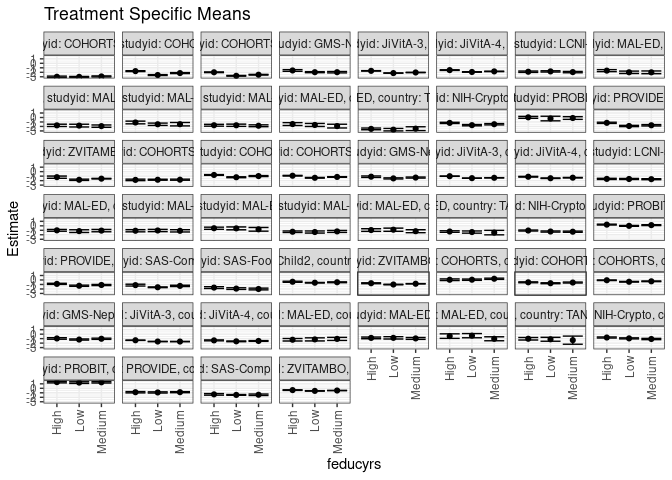

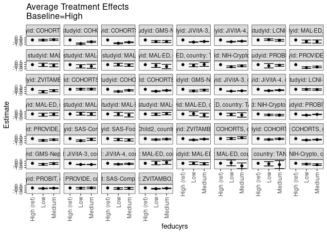

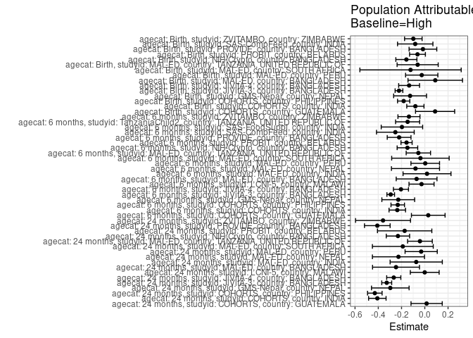

## Results Table

### Parameter: TSM

| agecat | studyid | country | intervention_level | baseline_level | estimate | ci_lower | ci_upper |
| --- | --- | --- | --- | --- | --- | --- | --- |
| Birth | COHORTS | GUATEMALA | High | NA | 0.0483226 | -0.1355878 | 0.2322330 |
| Birth | COHORTS | GUATEMALA | Low | NA | 0.0623099 | -0.0775841 | 0.2022038 |
| Birth | COHORTS | GUATEMALA | Medium | NA | 0.2736735 | 0.1393658 | 0.4079812 |
| Birth | COHORTS | INDIA | High | NA | -0.5201708 | -0.6170768 | -0.4232648 |
| Birth | COHORTS | INDIA | Low | NA | -0.7242825 | -0.8211851 | -0.6273799 |
| Birth | COHORTS | INDIA | Medium | NA | -0.5719845 | -0.6800311 | -0.4639379 |
| Birth | COHORTS | PHILIPPINES | High | NA | -0.0591431 | -0.1231379 | 0.0048516 |
| Birth | COHORTS | PHILIPPINES | Low | NA | -0.3975453 | -0.4734748 | -0.3216159 |
| Birth | COHORTS | PHILIPPINES | Medium | NA | -0.2964966 | -0.3640541 | -0.2289390 |
| Birth | GMS-Nepal | NEPAL | High | NA | -0.9620349 | -1.1262090 | -0.7978607 |
| Birth | GMS-Nepal | NEPAL | Low | NA | -1.2072297 | -1.3301803 | -1.0842792 |
| Birth | GMS-Nepal | NEPAL | Medium | NA | -1.0292920 | -1.1648673 | -0.8937168 |
| Birth | JiVitA-3 | BANGLADESH | High | NA | -1.3623868 | -1.4006967 | -1.3240769 |
| Birth | JiVitA-3 | BANGLADESH | Low | NA | -1.6437579 | -1.6704427 | -1.6170732 |
| Birth | JiVitA-3 | BANGLADESH | Medium | NA | -1.6498654 | -1.6808504 | -1.6188804 |
| Birth | JiVitA-4 | BANGLADESH | High | NA | -1.3892955 | -1.4899262 | -1.2886649 |
| Birth | JiVitA-4 | BANGLADESH | Low | NA | -1.6022142 | -1.6771597 | -1.5272686 |
| Birth | JiVitA-4 | BANGLADESH | Medium | NA | -1.5171970 | -1.6036981 | -1.4306959 |
| Birth | MAL-ED | BANGLADESH | High | NA | -1.2508511 | -1.5267620 | -0.9749402 |
| Birth | MAL-ED | BANGLADESH | Low | NA | -1.1713889 | -1.5155255 | -0.8272522 |
| Birth | MAL-ED | BANGLADESH | Medium | NA | -1.0608696 | -1.4016531 | -0.7200860 |
| Birth | MAL-ED | PERU | High | NA | -0.8381395 | -1.0225089 | -0.6537702 |
| Birth | MAL-ED | PERU | Low | NA | -0.8277586 | -1.0842786 | -0.5712386 |
| Birth | MAL-ED | PERU | Medium | NA | -0.9526000 | -1.1579670 | -0.7472330 |
| Birth | MAL-ED | SOUTH AFRICA | High | NA | -0.4350000 | -0.9433959 | 0.0733959 |
| Birth | MAL-ED | SOUTH AFRICA | Low | NA | -0.3378571 | -0.8038006 | 0.1280863 |
| Birth | MAL-ED | SOUTH AFRICA | Medium | NA | -1.0355556 | -1.4792485 | -0.5918626 |
| Birth | MAL-ED | TANZANIA, UNITED REPUBLIC OF | High | NA | -1.0292424 | -1.3067143 | -0.7517706 |
| Birth | MAL-ED | TANZANIA, UNITED REPUBLIC OF | Low | NA | -1.1474074 | -1.5853760 | -0.7094388 |
| Birth | MAL-ED | TANZANIA, UNITED REPUBLIC OF | Medium | NA | -1.3430000 | -2.2507162 | -0.4352838 |

[output cut: 126 more lines]

### Parameter: E(Y)

| agecat | studyid | country | intervention_level | baseline_level | estimate | ci_lower | ci_upper |
| --- | --- | --- | --- | --- | --- | --- | --- |
| Birth | COHORTS | GUATEMALA | NA | NA | 0.1369030 | 0.0500914 | 0.2237146 |
| Birth | COHORTS | INDIA | NA | NA | -0.6011965 | -0.6594222 | -0.5429708 |
| Birth | COHORTS | PHILIPPINES | NA | NA | -0.2407379 | -0.2807613 | -0.2007145 |
| Birth | GMS-Nepal | NEPAL | NA | NA | -1.0885159 | -1.1686181 | -1.0084136 |
| Birth | JiVitA-3 | BANGLADESH | NA | NA | -1.5843618 | -1.6039583 | -1.5647653 |
| Birth | JiVitA-4 | BANGLADESH | NA | NA | -1.5242226 | -1.5742923 | -1.4741529 |
| Birth | MAL-ED | BANGLADESH | NA | NA | -1.1609302 | -1.3461119 | -0.9757486 |
| Birth | MAL-ED | PERU | NA | NA | -0.8645361 | -0.9887014 | -0.7403707 |
| Birth | MAL-ED | SOUTH AFRICA | NA | NA | -0.5575758 | -0.8541170 | -0.2610345 |
| Birth | MAL-ED | TANZANIA, UNITED REPUBLIC OF | NA | NA | -1.0906796 | -1.3207118 | -0.8606474 |
| Birth | NIH-Crypto | BANGLADESH | NA | NA | -0.9094945 | -0.9809370 | -0.8380521 |
| Birth | PROBIT | BELARUS | NA | NA | 1.3196253 | 1.1597759 | 1.4794747 |
| Birth | PROVIDE | BANGLADESH | NA | NA | -0.8851020 | -0.9601332 | -0.8100709 |
| Birth | SAS-CompFeed | INDIA | NA | NA | -1.4300160 | -1.5090211 | -1.3510109 |
| Birth | ZVITAMBO | ZIMBABWE | NA | NA | -0.4977261 | -0.5185420 | -0.4769102 |
| 6 months | COHORTS | GUATEMALA | NA | NA | -1.8074115 | -1.8776669 | -1.7371562 |
| 6 months | COHORTS | INDIA | NA | NA | -0.9755018 | -1.0332483 | -0.9177553 |
| 6 months | COHORTS | PHILIPPINES | NA | NA | -1.1419345 | -1.1847445 | -1.0991244 |
| 6 months | GMS-Nepal | NEPAL | NA | NA | -1.3525459 | -1.4308373 | -1.2742545 |
| 6 months | JiVitA-3 | BANGLADESH | NA | NA | -1.3073109 | -1.3309979 | -1.2836240 |
| 6 months | JiVitA-4 | BANGLADESH | NA | NA | -1.3420154 | -1.3798750 | -1.3041557 |
| 6 months | LCNI-5 | MALAWI | NA | NA | -1.6442734 | -1.7137349 | -1.5748119 |
| 6 months | MAL-ED | BANGLADESH | NA | NA | -1.0786869 | -1.2229595 | -0.9344142 |
| 6 months | MAL-ED | INDIA | NA | NA | -1.0820652 | -1.2263805 | -0.9377499 |
| 6 months | MAL-ED | NEPAL | NA | NA | -0.6179474 | -0.8011766 | -0.4347182 |
| 6 months | MAL-ED | PERU | NA | NA | -1.3208519 | -1.4383850 | -1.2033189 |
| 6 months | MAL-ED | SOUTH AFRICA | NA | NA | -0.9829167 | -1.1753367 | -0.7904967 |
| 6 months | MAL-ED | TANZANIA, UNITED REPUBLIC OF | NA | NA | -1.3283002 | -1.4654809 | -1.1911194 |
| 6 months | NIH-Crypto | BANGLADESH | NA | NA | -1.1986783 | -1.2700937 | -1.1272630 |
| 6 months | PROBIT | BELARUS | NA | NA | 0.1078936 | 0.0168981 | 0.1988891 |
| 6 months | PROVIDE | BANGLADESH | NA | NA | -1.0916915 | -1.1661176 | -1.0172654 |
| 6 months | SAS-CompFeed | INDIA | NA | NA | -1.4006377 | -1.4802862 | -1.3209891 |
| 6 months | SAS-FoodSuppl | INDIA | NA | NA | -1.8986842 | -2.0118892 | -1.7854792 |
| 6 months | TanzaniaChild2 | TANZANIA, UNITED REPUBLIC OF | NA | NA | -0.5442042 | -0.5932639 | -0.4951446 |
| 6 months | ZVITAMBO | ZIMBABWE | NA | NA | -0.8606958 | -0.8865994 | -0.8347923 |
| 24 months | COHORTS | GUATEMALA | NA | NA | -2.9834879 | -3.0503374 | -2.9166384 |
| 24 months | COHORTS | INDIA | NA | NA | -2.1479058 | -2.2089283 | -2.0868833 |
| 24 months | COHORTS | PHILIPPINES | NA | NA | -2.4268626 | -2.4728444 | -2.3808807 |
| 24 months | GMS-Nepal | NEPAL | NA | NA | -1.8889117 | -1.9744778 | -1.8033456 |
| 24 months | JiVitA-3 | BANGLADESH | NA | NA | -2.0070517 | -2.0348225 | -1.9792810 |
| 24 months | JiVitA-4 | BANGLADESH | NA | NA | -1.7817125 | -1.8182569 | -1.7451681 |
| 24 months | LCNI-5 | MALAWI | NA | NA | -1.8787566 | -1.9605168 | -1.7969964 |
| 24 months | MAL-ED | BANGLADESH | NA | NA | -1.8767521 | -2.0339896 | -1.7195147 |
| 24 months | MAL-ED | INDIA | NA | NA | -1.8269318 | -1.9896129 | -1.6642507 |
| 24 months | MAL-ED | NEPAL | NA | NA | -1.3417582 | -1.5289233 | -1.1545932 |
| 24 months | MAL-ED | PERU | NA | NA | -1.7589939 | -1.8878675 | -1.6301203 |
| 24 months | MAL-ED | SOUTH AFRICA | NA | NA | -1.6565385 | -1.8628022 | -1.4502747 |
| 24 months | MAL-ED | TANZANIA, UNITED REPUBLIC OF | NA | NA | -2.5846893 | -2.7309103 | -2.4384682 |
| 24 months | NIH-Crypto | BANGLADESH | NA | NA | -1.4412646 | -1.5249156 | -1.3576135 |
| 24 months | PROBIT | BELARUS | NA | NA | -0.1374857 | -0.4188811 | 0.1439096 |
| 24 months | PROVIDE | BANGLADESH | NA | NA | -1.6024221 | -1.6857420 | -1.5191023 |
| 24 months | ZVITAMBO | ZIMBABWE | NA | NA | -1.5903795 | -1.6477380 | -1.5330211 |

### Parameter: ATE

| agecat | studyid | country | intervention_level | baseline_level | estimate | ci_lower | ci_upper |
| --- | --- | --- | --- | --- | --- | --- | --- |
| Birth | COHORTS | GUATEMALA | High | High | 0.0000000 | 0.0000000 | 0.0000000 |
| Birth | COHORTS | GUATEMALA | Low | High | 0.0139873 | -0.2170828 | 0.2450573 |
| Birth | COHORTS | GUATEMALA | Medium | High | 0.2253509 | -0.0023805 | 0.4530823 |
| Birth | COHORTS | INDIA | High | High | 0.0000000 | 0.0000000 | 0.0000000 |
| Birth | COHORTS | INDIA | Low | High | -0.2041117 | -0.3411551 | -0.0670683 |
| Birth | COHORTS | INDIA | Medium | High | -0.0518138 | -0.1969511 | 0.0933236 |
| Birth | COHORTS | PHILIPPINES | High | High | 0.0000000 | 0.0000000 | 0.0000000 |
| Birth | COHORTS | PHILIPPINES | Low | High | -0.3384022 | -0.4377028 | -0.2391016 |
| Birth | COHORTS | PHILIPPINES | Medium | High | -0.2373534 | -0.3304090 | -0.1442978 |
| Birth | GMS-Nepal | NEPAL | High | High | 0.0000000 | 0.0000000 | 0.0000000 |
| Birth | GMS-Nepal | NEPAL | Low | High | -0.2451948 | -0.4503045 | -0.0400851 |
| Birth | GMS-Nepal | NEPAL | Medium | High | -0.0672572 | -0.2801745 | 0.1456602 |
| Birth | JiVitA-3 | BANGLADESH | High | High | 0.0000000 | 0.0000000 | 0.0000000 |
| Birth | JiVitA-3 | BANGLADESH | Low | High | -0.2813711 | -0.3273170 | -0.2354252 |
| Birth | JiVitA-3 | BANGLADESH | Medium | High | -0.2874786 | -0.3348242 | -0.2401331 |
| Birth | JiVitA-4 | BANGLADESH | High | High | 0.0000000 | 0.0000000 | 0.0000000 |
| Birth | JiVitA-4 | BANGLADESH | Low | High | -0.2129186 | -0.3364449 | -0.0893923 |
| Birth | JiVitA-4 | BANGLADESH | Medium | High | -0.1279014 | -0.2594689 | 0.0036660 |
| Birth | MAL-ED | BANGLADESH | High | High | 0.0000000 | 0.0000000 | 0.0000000 |
| Birth | MAL-ED | BANGLADESH | Low | High | 0.0794622 | -0.3616238 | 0.5205482 |
| Birth | MAL-ED | BANGLADESH | Medium | High | 0.1899815 | -0.2484934 | 0.6284564 |
| Birth | MAL-ED | PERU | High | High | 0.0000000 | 0.0000000 | 0.0000000 |
| Birth | MAL-ED | PERU | Low | High | 0.0103809 | -0.3055218 | 0.3262837 |
| Birth | MAL-ED | PERU | Medium | High | -0.1144605 | -0.3904453 | 0.1615244 |
| Birth | MAL-ED | SOUTH AFRICA | High | High | 0.0000000 | 0.0000000 | 0.0000000 |
| Birth | MAL-ED | SOUTH AFRICA | Low | High | 0.0971429 | -0.5924727 | 0.7867584 |
| Birth | MAL-ED | SOUTH AFRICA | Medium | High | -0.6005556 | -1.2753368 | 0.0742257 |
| Birth | MAL-ED | TANZANIA, UNITED REPUBLIC OF | High | High | 0.0000000 | 0.0000000 | 0.0000000 |
| Birth | MAL-ED | TANZANIA, UNITED REPUBLIC OF | Low | High | -0.1181650 | -0.6366311 | 0.4003011 |
| Birth | MAL-ED | TANZANIA, UNITED REPUBLIC OF | Medium | High | -0.3137576 | -1.2629359 | 0.6354207 |

[output cut: 126 more lines]

### Parameter: PAR

| agecat | studyid | country | intervention_level | baseline_level | estimate | ci_lower | ci_upper |
| --- | --- | --- | --- | --- | --- | --- | --- |
| Birth | COHORTS | GUATEMALA | High | NA | 0.0885804 | -0.0796994 | 0.2568602 |
| Birth | COHORTS | INDIA | High | NA | -0.0810257 | -0.1549913 | -0.0070601 |
| Birth | COHORTS | PHILIPPINES | High | NA | -0.1815948 | -0.2342191 | -0.1289705 |
| Birth | GMS-Nepal | NEPAL | High | NA | -0.1264810 | -0.2679357 | 0.0149738 |
| Birth | JiVitA-3 | BANGLADESH | High | NA | -0.2219750 | -0.2552029 | -0.1887472 |
| Birth | JiVitA-4 | BANGLADESH | High | NA | -0.1349271 | -0.2245750 | -0.0452792 |
| Birth | MAL-ED | BANGLADESH | High | NA | 0.0899208 | -0.1444865 | 0.3243282 |
| Birth | MAL-ED | PERU | High | NA | -0.0263965 | -0.1652195 | 0.1124264 |
| Birth | MAL-ED | SOUTH AFRICA | High | NA | -0.1225758 | -0.5581866 | 0.3130351 |
| Birth | MAL-ED | TANZANIA, UNITED REPUBLIC OF | High | NA | -0.0614372 | -0.2381795 | 0.1153051 |
| Birth | NIH-Crypto | BANGLADESH | High | NA | -0.1584382 | -0.2490219 | -0.0678545 |
| Birth | PROBIT | BELARUS | High | NA | -0.0627084 | -0.1306942 | 0.0052775 |
| Birth | PROVIDE | BANGLADESH | High | NA | -0.0160223 | -0.1350742 | 0.1030296 |
| Birth | SAS-CompFeed | INDIA | High | NA | -0.0822568 | -0.2343754 | 0.0698618 |
| Birth | ZVITAMBO | ZIMBABWE | High | NA | -0.0986222 | -0.1739531 | -0.0232913 |
| 6 months | COHORTS | GUATEMALA | High | NA | 0.0297400 | -0.1149271 | 0.1744071 |
| 6 months | COHORTS | INDIA | High | NA | -0.2366231 | -0.3076339 | -0.1656124 |
| 6 months | COHORTS | PHILIPPINES | High | NA | -0.2326415 | -0.2906532 | -0.1746299 |
| 6 months | GMS-Nepal | NEPAL | High | NA | -0.2282028 | -0.3692133 | -0.0871923 |
| 6 months | JiVitA-3 | BANGLADESH | High | NA | -0.2929571 | -0.3256858 | -0.2602284 |
| 6 months | JiVitA-4 | BANGLADESH | High | NA | -0.2049771 | -0.2696500 | -0.1403043 |
| 6 months | LCNI-5 | MALAWI | High | NA | -0.0280981 | -0.1358725 | 0.0796763 |
| 6 months | MAL-ED | BANGLADESH | High | NA | -0.0705202 | -0.2458793 | 0.1048389 |
| 6 months | MAL-ED | INDIA | High | NA | 0.0190976 | -0.1870751 | 0.2252702 |
| 6 months | MAL-ED | NEPAL | High | NA | -0.0799474 | -0.2867014 | 0.1268067 |
| 6 months | MAL-ED | PERU | High | NA | 0.0038443 | -0.1191245 | 0.1268131 |
| 6 months | MAL-ED | SOUTH AFRICA | High | NA | -0.0375126 | -0.2847412 | 0.2097160 |
| 6 months | MAL-ED | TANZANIA, UNITED REPUBLIC OF | High | NA | -0.0553605 | -0.1601333 | 0.0494123 |
| 6 months | NIH-Crypto | BANGLADESH | High | NA | -0.1493414 | -0.2377547 | -0.0609281 |
| 6 months | PROBIT | BELARUS | High | NA | -0.1569830 | -0.2050101 | -0.1089560 |
| 6 months | PROVIDE | BANGLADESH | High | NA | -0.2208462 | -0.3229811 | -0.1187113 |
| 6 months | SAS-CompFeed | INDIA | High | NA | -0.2531233 | -0.4152824 | -0.0909642 |
| 6 months | SAS-FoodSuppl | INDIA | High | NA | -0.1966050 | -0.3747455 | -0.0184645 |
| 6 months | TanzaniaChild2 | TANZANIA, UNITED REPUBLIC OF | High | NA | -0.1477532 | -0.2511807 | -0.0443257 |
| 6 months | ZVITAMBO | ZIMBABWE | High | NA | -0.1362248 | -0.2308832 | -0.0415664 |
| 24 months | COHORTS | GUATEMALA | High | NA | 0.0157776 | -0.1185058 | 0.1500610 |
| 24 months | COHORTS | INDIA | High | NA | -0.4081470 | -0.4832208 | -0.3330731 |
| 24 months | COHORTS | PHILIPPINES | High | NA | -0.4296947 | -0.4922068 | -0.3671825 |
| 24 months | GMS-Nepal | NEPAL | High | NA | -0.2966403 | -0.4582991 | -0.1349816 |
| 24 months | JiVitA-3 | BANGLADESH | High | NA | -0.3273947 | -0.3701000 | -0.2846895 |
| 24 months | JiVitA-4 | BANGLADESH | High | NA | -0.2669497 | -0.3276675 | -0.2062319 |
| 24 months | LCNI-5 | MALAWI | High | NA | -0.0005774 | -0.1245348 | 0.1233801 |
| 24 months | MAL-ED | BANGLADESH | High | NA | -0.2475021 | -0.4493113 | -0.0456929 |
| 24 months | MAL-ED | INDIA | High | NA | -0.0737175 | -0.2981268 | 0.1506917 |
| 24 months | MAL-ED | NEPAL | High | NA | -0.2264951 | -0.4504252 | -0.0025650 |
| 24 months | MAL-ED | PERU | High | NA | -0.0311800 | -0.1695877 | 0.1072276 |
| 24 months | MAL-ED | SOUTH AFRICA | High | NA | -0.1888914 | -0.4505321 | 0.0727493 |
| 24 months | MAL-ED | TANZANIA, UNITED REPUBLIC OF | High | NA | -0.0417507 | -0.1479883 | 0.0644870 |
| 24 months | NIH-Crypto | BANGLADESH | High | NA | -0.2309802 | -0.3314124 | -0.1305480 |
| 24 months | PROBIT | BELARUS | High | NA | -0.1732805 | -0.4070428 | 0.0604818 |
| 24 months | PROVIDE | BANGLADESH | High | NA | -0.4083380 | -0.5186120 | -0.2980640 |
| 24 months | ZVITAMBO | ZIMBABWE | High | NA | -0.3591816 | -0.5954949 | -0.1228684 |